# Fraud Detection in Vehicle Insurance Claims

#### A project on Supervised Machine Learning using Classification Models

**Team**:

- Ganesh Raj G
- Shalini K
- Wenhan X

## Objective

Develop and implement an end-to-end machine learning pipeline to train multiple supervised classification models that predict vehicle insurance fraud probabilities, and to select the best model based on high ROC AUC and Recall scores to minimize company financial losses. The pipeline includes data preprocessing, class imbalance handling, model training, hyperparameters tuning, evaluation using target metrics, and selection of the optimal model.

- Dataset from kaggle (https://www.kaggle.com/datasets/arpan129/insurance-fraud-detection/data):

We plan to do

- Exploratory Data Analysis (EDA) )
- Data cleaning & handling of missing values
- Feature Engineering
- Encoding of categorical variables
- Feature scaling for numeric features
- Handling class imbalance
- Training and Evaluation of Classification Models
  - Logistic Regression
  - Support Vector Machines (SVM)
  - Decision Tree
  - Random Forest
  - K-Nearest Neighbors (KNN)
- Hyperparameter Tuning
- Compare and and find best model based on ROC AUC (and Recall)
- Conclusion & Future Steps

The target variable is **`fraud_reported`** with values `'Y'` and `'N'`.

## Exploratory Data Analysis (EDA)

```python
# Basic libraries for data manipulation and visualization
import numpy as np
import pandas as pd
import matplotlib.pyplot as plt

# Scikit-learn modules for model selection, preprocessing, and pipelines
from sklearn.model_selection import train_test_split, RandomizedSearchCV
from sklearn.compose import ColumnTransformer
from sklearn.preprocessing import OneHotEncoder, MinMaxScaler
from sklearn.pipeline import Pipeline

# Scikit-learn classification models
from sklearn.linear_model import LogisticRegression
from sklearn.tree import DecisionTreeClassifier
from sklearn.ensemble import RandomForestClassifier # Removed GradientBoostingClassifier, LightGBM, XGBoost for now
from sklearn.svm import SVC
from sklearn.neighbors import KNeighborsClassifier

# Scikit-learn metrics for model evaluation
from sklearn.metrics import (
    accuracy_score,
    precision_score,
    recall_score,
    f1_score,
    roc_auc_score,
    confusion_matrix,
    classification_report
)

# Ignore warnings for cleaner output
import warnings
warnings.filterwarnings('ignore')

# Set a random state for reproducibility
RANDOM_STATE = 42
```

```python
# Define the file path for the dataset
file_path = "fraud_insurance_claims_dataset.xlsx"

# Load the Excel file into a pandas DataFrame
df = pd.read_excel(file_path)

# Print the shape of the DataFrame (rows, columns)
print("Shape:", df.shape)

# Display the first 5 rows of the DataFrame
df.head()
```

```
Shape: (1000, 39)
```

|  | months_as_customer | age | policy_number | policy_bind_date | policy_state | policy_csl | policy_deductable | policy_annual_premium | umbrella_limit | insured_zip | ... | witnesses | police_report_available | total_claim_amount | injury_claim | property_claim | vehicle_claim | auto_make | auto_model | auto_year | fraud_reported |
| --- | --- | --- | --- | --- | --- | --- | --- | --- | --- | --- | --- | --- | --- | --- | --- | --- | --- | --- | --- | --- | --- |
| 0 | 328 | 48 | 521585 | 2014-10-17 | OH | 250/500 | 1000 | 1406.91 | 0 | 466132 | ... | 2 | YES | 71610 | 6510 | 13020 | 52080 | Saab | 92x | 2004 | Y |
| 1 | 228 | 42 | 342868 | 2006-06-27 | IN | 250/500 | 2000 | 1197.22 | 5000000 | 468176 | ... | 0 | ? | 5070 | 780 | 780 | 3510 | Mercedes | E400 | 2007 | Y |
| 2 | 134 | 29 | 687698 | 2000-09-06 | OH | 100/300 | 2000 | 1413.14 | 5000000 | 430632 | ... | 3 | NO | 34650 | 7700 | 3850 | 23100 | Dodge | RAM | 2007 | N |
| 3 | 256 | 41 | 227811 | 1990-05-25 | IL | 250/500 | 2000 | 1415.74 | 6000000 | 608117 | ... | 2 | NO | 63400 | 6340 | 6340 | 50720 | Chevrolet | Tahoe | 2014 | Y |
| 4 | 228 | 44 | 367455 | 2014-06-06 | IL | 500/1000 | 1000 | 1583.91 | 6000000 | 610706 | ... | 1 | NO | 6500 | 1300 | 650 | 4550 | Accura | RSX | 2009 | N |

5 rows × 39 columns

```python
# Define a function to quickly inspect DataFrame characteristics
def check_data(data):
    return (pd.DataFrame({
        'type': data.dtypes, # Data type of each column
        'amount_unique': data.nunique(), # Number of unique values in each column
        'unique_values': [data[x].unique() for x in data.columns], # List of unique values in each column
        'null_values': data.isna().sum(), # Count of null (NaN) values in each column
    }))
```

```python
# Print the shape of the DataFrame again for quick reference
print("Shape:", df.shape)

# Use the custom function to get an overview of the data
# Sort by 'amount_unique' to see highly unique columns first (potential identifiers) and low unique columns (potential categorical features)
check_data(df).sort_values("amount_unique", ascending=False)
```

```
Shape: (1000, 39)
```

|  | type | amount_unique | unique_values | null_values |
| --- | --- | --- | --- | --- |
| policy_number | int64 | 1000 | [521585, 342868, 687698, 227811, 367455, 10459... | 0 |
| incident_location | object | 1000 | [9935 4th Drive, 6608 MLK Hwy, 7121 Francis La... | 0 |
| insured_zip | int64 | 995 | [466132, 468176, 430632, 608117, 610706, 47845... | 0 |
| policy_annual_premium | float64 | 991 | [1406.91, 1197.22, 1413.14, 1415.74, 1583.91, ... | 0 |
| policy_bind_date | datetime64[ns] | 951 | [2014-10-17 00:00:00, 2006-06-27 00:00:00, 200... | 0 |
| total_claim_amount | int64 | 763 | [71610, 5070, 34650, 63400, 6500, 64100, 78650... | 0 |
| vehicle_claim | int64 | 726 | [52080, 3510, 23100, 50720, 4550, 51280, 50050... | 0 |
| injury_claim | int64 | 638 | [6510, 780, 7700, 6340, 1300, 6410, 21450, 938... | 0 |
| property_claim | int64 | 626 | [13020, 780, 3850, 6340, 650, 6410, 7150, 9380... | 0 |
| months_as_customer | int64 | 391 | [328, 228, 134, 256, 137, 165, 27, 212, 235, 4... | 0 |
| capital-loss | int64 | 354 | [0, -62400, -46000, -77000, -39300, -51000, -3... | 0 |
| capital-gains | int64 | 338 | [53300, 0, 35100, 48900, 66000, 38400, 52800, ... | 0 |
| incident_date | datetime64[ns] | 60 | [2015-01-25 00:00:00, 2015-01-21 00:00:00, 201... | 0 |
| age | int64 | 46 | [48, 42, 29, 41, 44, 39, 34, 37, 33, 61, 23, 3... | 0 |
| auto_model | object | 39 | [92x, E400, RAM, Tahoe, RSX, 95, Pathfinder, A... | 0 |
| incident_hour_of_the_day | int64 | 24 | [5, 8, 7, 20, 19, 0, 23, 21, 14, 22, 9, 12, 15... | 0 |
| auto_year | int64 | 21 | [2004, 2007, 2014, 2009, 2003, 2012, 2015, 199... | 0 |
| insured_hobbies | object | 20 | [sleeping, reading, board-games, bungie-jumpin... | 0 |
| insured_occupation | object | 14 | [craft-repair, machine-op-inspct, sales, armed... | 0 |
| auto_make | object | 14 | [Saab, Mercedes, Dodge, Chevrolet, Accura, Nis... | 0 |
| umbrella_limit | int64 | 11 | [0, 5000000, 6000000, 4000000, 3000000, 800000... | 0 |
| incident_state | object | 7 | [SC, VA, NY, OH, WV, NC, PA] | 0 |
| incident_city | object | 7 | [Columbus, Riverwood, Arlington, Springfield, ... | 0 |
| insured_education_level | object | 7 | [MD, PhD, Associate, Masters, High School, Col... | 0 |
| insured_relationship | object | 6 | [husband, other-relative, own-child, unmarried... | 0 |
| witnesses | int64 | 4 | [2, 0, 3, 1] | 0 |
| authorities_contacted | object | 4 | [Police, nan, Fire, Other, Ambulance] | 91 |
| number_of_vehicles_involved | int64 | 4 | [1, 3, 4, 2] | 0 |
| incident_type | object | 4 | [Single Vehicle Collision, Vehicle Theft, Mult... | 0 |
| collision_type | object | 4 | [Side Collision, ?, Rear Collision, Front Coll... | 0 |
| incident_severity | object | 4 | [Major Damage, Minor Damage, Total Loss, Trivi... | 0 |
| policy_deductable | int64 | 3 | [1000, 2000, 500] | 0 |
| policy_csl | object | 3 | [250/500, 100/300, 500/1000] | 0 |
| policy_state | object | 3 | [OH, IN, IL] | 0 |
| police_report_available | object | 3 | [YES, ?, NO] | 0 |
| property_damage | object | 3 | [YES, ?, NO] | 0 |
| bodily_injuries | int64 | 3 | [1, 0, 2] | 0 |
| insured_sex | object | 2 | [MALE, FEMALE] | 0 |
| fraud_reported | object | 2 | [Y, N] | 0 |

```python
# Display descriptive statistics for numerical columns
df.describe().T.round(2)
```

|  | count | mean | min | 25% | 50% | 75% | max | std |
| --- | --- | --- | --- | --- | --- | --- | --- | --- |
| months_as_customer | 1000.0 | 203.954 | 0.0 | 115.75 | 199.5 | 276.25 | 479.0 | 115.113174 |
| age | 1000.0 | 38.948 | 19.0 | 32.0 | 38.0 | 44.0 | 64.0 | 9.140287 |
| policy_number | 1000.0 | 546238.648 | 100804.0 | 335980.25 | 533135.0 | 759099.75 | 999435.0 | 257063.005276 |
| policy_bind_date | 1000 | 2002-02-08 04:40:47.999999872 | 1990-01-08 00:00:00 | 1995-09-19 00:00:00 | 2002-04-01 12:00:00 | 2008-04-21 12:00:00 | 2015-02-22 00:00:00 | NaN |
| policy_deductable | 1000.0 | 1136.0 | 500.0 | 500.0 | 1000.0 | 2000.0 | 2000.0 | 611.864673 |
| policy_annual_premium | 1000.0 | 1256.40615 | 433.33 | 1089.6075 | 1257.2 | 1415.695 | 2047.59 | 244.167395 |
| umbrella_limit | 1000.0 | 1101000.0 | -1000000.0 | 0.0 | 0.0 | 0.0 | 10000000.0 | 2297406.598118 |
| insured_zip | 1000.0 | 501214.488 | 430104.0 | 448404.5 | 466445.5 | 603251.0 | 620962.0 | 71701.610941 |
| capital-gains | 1000.0 | 25126.1 | 0.0 | 0.0 | 0.0 | 51025.0 | 100500.0 | 27872.187708 |
| capital-loss | 1000.0 | -26793.7 | -111100.0 | -51500.0 | -23250.0 | 0.0 | 0.0 | 28104.096686 |
| incident_date | 1000 | 2015-01-30 08:02:24 | 2015-01-01 00:00:00 | 2015-01-15 00:00:00 | 2015-01-31 00:00:00 | 2015-02-15 00:00:00 | 2015-03-01 00:00:00 | NaN |
| incident_hour_of_the_day | 1000.0 | 11.644 | 0.0 | 6.0 | 12.0 | 17.0 | 23.0 | 6.951373 |
| number_of_vehicles_involved | 1000.0 | 1.839 | 1.0 | 1.0 | 1.0 | 3.0 | 4.0 | 1.01888 |
| bodily_injuries | 1000.0 | 0.992 | 0.0 | 0.0 | 1.0 | 2.0 | 2.0 | 0.820127 |
| witnesses | 1000.0 | 1.487 | 0.0 | 1.0 | 1.0 | 2.0 | 3.0 | 1.111335 |
| total_claim_amount | 1000.0 | 52761.94 | 100.0 | 41812.5 | 58055.0 | 70592.5 | 114920.0 | 26401.53319 |
| injury_claim | 1000.0 | 7433.42 | 0.0 | 4295.0 | 6775.0 | 11305.0 | 21450.0 | 4880.951853 |
| property_claim | 1000.0 | 7399.57 | 0.0 | 4445.0 | 6750.0 | 10885.0 | 23670.0 | 4824.726179 |
| vehicle_claim | 1000.0 | 37928.95 | 70.0 | 30292.5 | 42100.0 | 50822.5 | 79560.0 | 18886.252893 |
| auto_year | 1000.0 | 2005.103 | 1995.0 | 2000.0 | 2005.0 | 2010.0 | 2015.0 | 6.015861 |

#### Count analysis for categorical features

```python
# Perform a count analysis for all categorical (object type) columns
print("\nCount Analysis of categorical columns:")
for col in df.select_dtypes(include="object").columns:
    print(f"\nColumn: {col}")
    # Display the top 5 most frequent values and their counts
    print(df[col].value_counts().head())
```

```
Count Analysis of categorical columns:

Column: policy_state
policy_state
OH    352
IL    338
IN    310
Name: count, dtype: int64

Column: policy_csl
policy_csl
250/500     351
100/300     349
500/1000    300
Name: count, dtype: int64

Column: insured_sex
insured_sex
FEMALE    537
MALE      463
Name: count, dtype: int64

Column: insured_education_level
insured_education_level
JD             161
High School    160
Associate      145
MD             144
Masters        143
Name: count, dtype: int64

Column: insured_occupation
insured_occupation
machine-op-inspct    93
prof-specialty       85
tech-support         78
sales                76
exec-managerial      76
Name: count, dtype: int64

```

[output cut: 99 more lines]

```

Column: auto_model
auto_model
RAM         43
Wrangler    42
A3          37
Neon        37
MDX         36
Name: count, dtype: int64

Column: fraud_reported
fraud_reported
N    753
Y    247
Name: count, dtype: int64
```

## Initial EDA Observations

- Some categorical features have null values (`authorities_contacted`)
- Some categorical features have many missing values in the form of '?' value. This needs to be updated (`collision_type`, `property_damage`, `police_report_available`)
- However since we are working on fraud data, and because a considerable % values in a column are missing we will replace with 'Unknown' as it may represent suspicious data for fraud detection. Also the absence of information (e.g., a missing police report) is a predictive signal, not just noise.

## Data Cleaning

Only categorical columns have missing values, replacing them with Unknown

```python
# In this dataset, some missing values are encoded as '?' in categorical columns. Replace with Unknown
df = df.replace('?', 'Unknown')
# Only authorities_contacted has empty/na value, replace it with Unknown
df = df.fillna('Unknown')

# Verify that there are no more missing values (either '?' or NaN)
print("verify any more missing values (True/False) : ", df.isnull().values.any())
```

```
verify any more missing values (True/False) :  False
```

## Plotting

```
fraud_reported
N    753
Y    247
Name: count, dtype: int64

Class distribution (%):
fraud_reported
N    75.3
Y    24.7
Name: proportion, dtype: float64
```

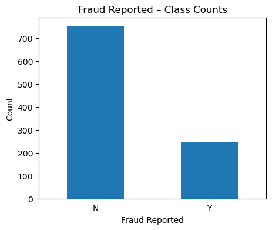

```python
# Target variable: fraud_reported ('Y' or 'N')

# Display the count of each class in the 'fraud_reported' column
print(df['fraud_reported'].value_counts())
# Display the class distribution as percentages
print("\nClass distribution (%):")
print(df['fraud_reported'].value_counts(normalize=True) * 100)

# Create a bar plot to visualize the distribution of the target variable
plt.figure(figsize=(5,4))
df['fraud_reported'].value_counts().plot(kind='bar')
plt.title("Fraud Reported – Class Counts") # Set plot title
plt.xlabel("Fraud Reported") # Set x-axis label
plt.ylabel("Count") # Set y-axis label
plt.xticks(rotation=0) # Ensure x-axis labels are horizontal
plt.show() # Display the plot
```

### Feature Distributions

```
Numeric columns: ['months_as_customer', 'age', 'policy_number', 'policy_deductable', 'policy_annual_premium', 'umbrella_limit', 'insured_zip', 'capital-gains', 'capital-loss', 'incident_hour_of_the_day', 'number_of_vehicles_involved', 'bodily_injuries', 'witnesses', 'total_claim_amount', 'injury_cla…

Categorical columns: ['policy_state', 'policy_csl', 'insured_sex', 'insured_education_level', 'insured_occupation', 'insured_hobbies', 'insured_relationship', 'incident_type', 'collision_type', 'incident_severity', 'authorities_contacted', 'incident_state', 'incident_city', 'incident_location', 'pro…
```

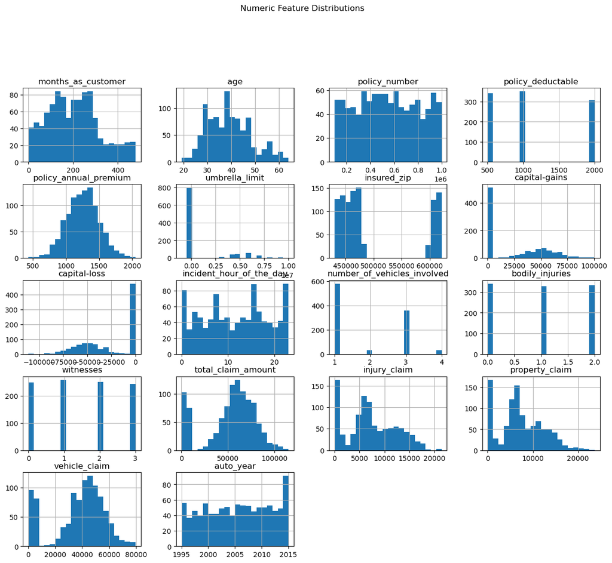

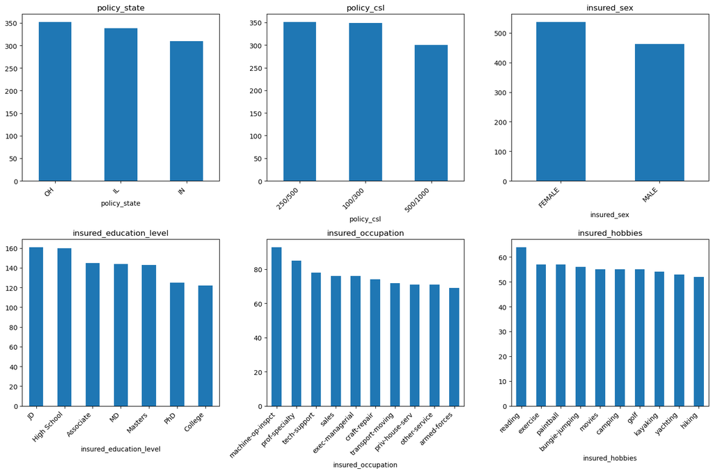

```python
# Separate numeric and categorical column names
numeric_cols = df.select_dtypes(include=['int64', 'float64']).columns.tolist()
categorical_cols = df.select_dtypes(include=['object']).columns.tolist()

print("Numeric columns:", numeric_cols)
print("\nCategorical columns:", categorical_cols)

# Plot histograms for numeric features to visualize their distributions
df[numeric_cols].hist(figsize=(15, 12), bins=20)
plt.suptitle("Numeric Feature Distributions", y=1.02)
plt.show()

# Plot bar plots for a few categorical variables to see their value counts
n_to_plot = min(6, len(categorical_cols)) # Plot up to 6 categorical features
plt.figure(figsize=(15, 10))
for i, col in enumerate(categorical_cols[:n_to_plot], 1):
    plt.subplot(2, 3, i) # =
    df[col].value_counts().head(10).plot(kind='bar') # Display top 10 categories
    plt.title(col) # Set subplot title
    plt.xticks(rotation=45, ha='right')
plt.tight_layout()
plt.show() # Display the plots
```

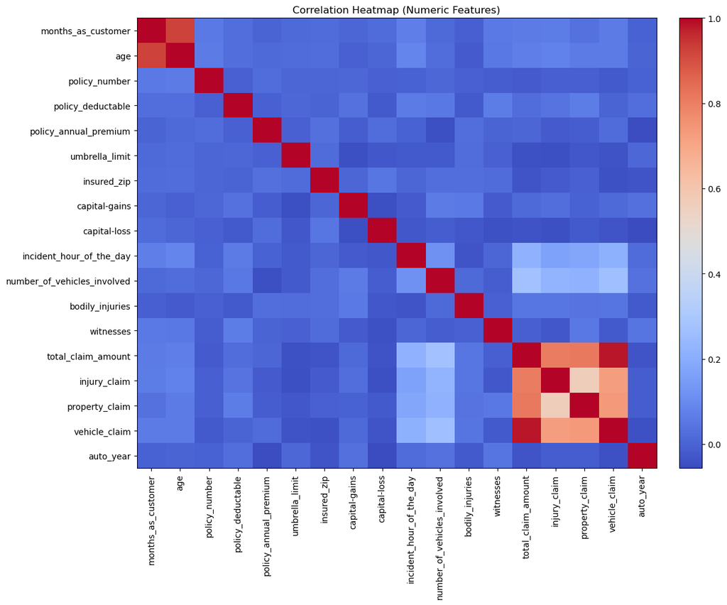

```python
# Create a correlation matrix for all numeric features
plt.figure(figsize=(12, 10))
corr = df[numeric_cols].corr()
# Display the correlation matrix as a heatmap
im = plt.imshow(corr, interpolation='nearest', aspect='auto', cmap='coolwarm')
plt.colorbar(im, fraction=0.046, pad=0.04)
plt.xticks(range(len(numeric_cols)), numeric_cols, rotation=90) # Set x-axis labels
plt.yticks(range(len(numeric_cols)), numeric_cols) # Set y-axis labels
plt.title("Correlation Heatmap (Numeric Features)")
plt.tight_layout()
plt.show() # Display the heatmap
```

## Analysis of fraud_reported = 'Y' with features

```python
# Get data overview
data_overview = check_data(df)

# Filter for columns with less than 30 unique values, as these are often categorical or binned
low_unique = data_overview[data_overview['amount_unique'] < 30]

# Extract the names of these columns
low_unique_cols = low_unique.index.tolist()

print("columns with less than 30 unique values:")
print(low_unique_cols)

# Filter to only include rows where 'fraud_reported' is 'Y'
df_fraud = df[df['fraud_reported'] == 'Y']
```

```
columns with less than 30 unique values:
['policy_state', 'policy_csl', 'policy_deductable', 'umbrella_limit', 'insured_sex', 'insured_education_level', 'insured_occupation', 'insured_hobbies', 'insured_relationship', 'incident_type', 'collision_type', 'incident_severity', 'authorities_contacted', 'incident_state', 'incident_city', 'incide…
```

```
Displaying data counts for 'Fraud' cases (247 records)
```

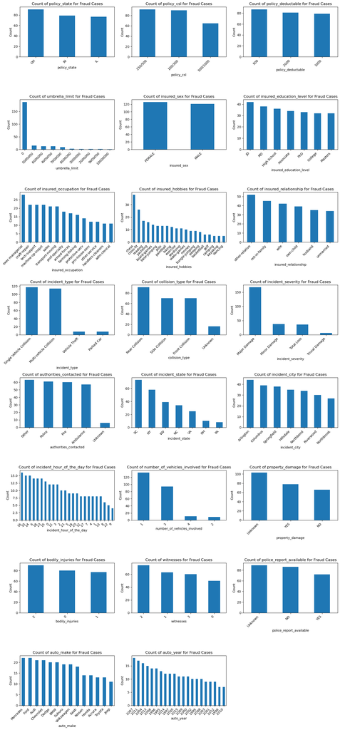

```python
# Exclude 'fraud_reported' itself from the list of features to plot
features_filtered = [col for col in low_unique_cols if col != 'fraud_reported']

# Print the number of fraud records for context
print(f"Displaying data counts for 'Fraud' cases ({len(df_fraud)} records)")

num_features = len(features_filtered)
cols = 3  # Number of columns for subplots
rows = (num_features + cols - 1) // cols  # Calculate required number of rows dynamically

# Create subplots to visualize the distribution of these features specifically for fraud cases
plt.figure(figsize=(5 * cols, 4 * rows))
for i, col in enumerate(features_filtered):
    plt.subplot(rows, cols, i + 1)
    # Plot value counts for each feature in the fraud subset
    df_fraud[col].value_counts().plot(kind='bar')
    plt.title(f'Count of {col} for Fraud Cases')
    plt.xlabel(col) # Set x-axis label
    plt.ylabel('Count') # Set y-axis label
    plt.xticks(rotation=45, ha='right')
plt.tight_layout()
plt.show() # Display the plots
```

## Additional Observations

- The dataset is moderately imbalanced, with Fraud (24.7%) vs. Non-Fraud (75.3%) Since we are working on fraud detection, it is important to ensure we handle imbalance
- The correlation heatmap shows that `total_claim_amount` is highly correlated with `vehicle_claim`, `property_claim` and `injury_claim`. This is expected since the total is the sum of sub-claims.
- Also `months_as_customer` is highly correlated with `age`
- Most of the features are not normally distributed

**Analyzing fraud_reported = 'Y' rows** we see that below categories have high fraud rates compared to others

- certain hobbies like Chess or Cross-fit
- insured occupation being executive/managerial
- having a Major vehicle damage
- incident states like SC or NY

## Feature engineering

```python
# Drop columns 'policy_number' and 'incident_location' as they are unique identifiers
# and do not provide generalizable patterns for fraud detection.
df.drop(['policy_number', 'incident_location'], axis=1, inplace=True)
```

```python
# Calculate 25th and 75th percentiles to define 'low' and 'high' thresholds for total_claim_amount
low_threshold = df['total_claim_amount'].quantile(0.25)
high_threshold = df['total_claim_amount'].quantile(0.75)

# Bin 'total_claim_amount' into three categories: 'low', 'medium', 'high'
df['total_claim_amount_bin'] = pd.cut(
    df['total_claim_amount'],
    bins=[df['total_claim_amount'].min() - 1, low_threshold, high_threshold, df['total_claim_amount'].max() + 1],
    labels=['low', 'medium', 'high'], # Assign descriptive labels to the bins
    right=True
)

# Drop the original 'total_claim_amount' column as it has been binned into a new feature
df = df.drop(columns=['total_claim_amount'])
```

Since `age` has correlation with `months_as_customer`, bin age into categories

```python
# Define custom age bins and corresponding labels
bins_age = [df['age'].min() - 1, 25, 35, 45, 55, df['age'].max() + 1]
labels_age = ['<25', '25 to 35', '35 to 45', '45 to 55', '55+']

# Bin the 'age' column into the defined categories
df['age_bin'] = pd.cut(df['age'], bins=bins_age, labels=labels_age, right=True)

# Drop the original 'age' column as it has been binned into a new feature
df = df.drop(columns=['age'])
```

Analyze `incident_hour_of_the_day` for binning

```
count    1000.000000
mean       11.644000
std         6.951373
min         0.000000
25%         6.000000
50%        12.000000
75%        17.000000
max        23.000000
Name: incident_hour_of_the_day, dtype: float64
```

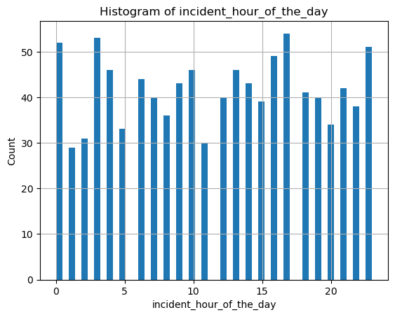

```
0.01     0.0
0.05     0.0
0.10     2.0
0.20     4.0
0.50    12.0
0.75    17.0
0.80    19.0
0.95    23.0
0.99    23.0
Name: incident_hour_of_the_day, dtype: float64
```

```python
# Display descriptive statistics for 'incident_hour_of_the_day'
print(df["incident_hour_of_the_day"].describe())

# Plot a histogram to visualize the distribution of incident hours
df["incident_hour_of_the_day"].hist(bins=50)
plt.xlabel("incident_hour_of_the_day") # Set x-axis label
plt.ylabel("Count") # Set y-axis label
plt.title("Histogram of incident_hour_of_the_day")
plt.show()

# Display various percentiles of 'incident_hour_of_the_day'
print(df["incident_hour_of_the_day"].quantile([0.01, 0.05, 0.10, 0.20, 0.50,
                                         0.75, 0.80, 0.95, 0.99]))
```

Bin `incident_hour_of_the_day` into 'early_morning', 'morning', 'afternoon', 'late_night'

```python
# Define bins and labels for 'incident_hour_of_the_day'
# Bins are set to represent common time periods: early morning, morning, afternoon, late night
bins_incident_hour = [df['incident_hour_of_the_day'].min() - 1, 6, 12, 18, df['incident_hour_of_the_day'].max() + 1]
labels_incident_hour = ['early_morning', 'morning', 'afternoon', 'late_night']

# Bin the 'incident_hour_of_the_day' column into the defined categories
df['incident_hour_bin'] = pd.cut(df['incident_hour_of_the_day'], bins=bins_incident_hour, labels=labels_incident_hour, right=False)

# Drop the original 'incident_hour_of_the_day' column as it has been binned into a new feature
df = df.drop(columns=['incident_hour_of_the_day'])
```

As Negative value of umbrella_limit is not allowed, change to absolute value

```python
# Convert any negative values in 'umbrella_limit' to their absolute (positive) values, Just 1 row had negative which seems data error
df['umbrella_limit'] = df['umbrella_limit'].abs()
```

- Creating new feature column `policy_days` = difference between `incident_date` and `policy_bind_date` in days
- Also creating new feature `incident_month` which has only month from `incident_date`
- Then drop both date features `policy_bind_date` and `incident_date`

```python
date_cols = []
# Iterate through potential date columns to ensure they are in datetime format
for col in ['policy_bind_date', 'incident_date']:
    if col in df.columns:
        date_cols.append(col)
        df[col] = pd.to_datetime(df[col], errors='coerce')

# Feature Engineering: Calculate 'policy_days' as the difference in days between incident date and policy bind date
df['policy_days'] = (df['incident_date'] - df['policy_bind_date']).dt.days

# Feature Engineering: Extract the month as an integer from 'incident_date'
df['incident_month'] = df['incident_date'].dt.month

# Drop the original raw date columns
df = df.drop(columns=date_cols, errors='ignore')
```

```python
# Map the target variable 'fraud_reported' from categorical ('Y', 'N') to numerical (1, 0)
df['fraud_reported'] = df['fraud_reported'].map({'Y': 1, 'N': 0})
```

```python
# Define feature matrix X by dropping the target variable 'fraud_reported'
X = df.drop(columns=['fraud_reported'])
# Define target vector y as the 'fraud_reported' column
y = df['fraud_reported']


# Re-identify numeric and categorical columns after feature engineering steps
# int32 is added to numeric types, as `pd.cut` can sometimes return int32 for binned columns
numeric_features = X.select_dtypes(include=['int32','int64', 'float64']).columns.tolist()
categorical_features = X.select_dtypes(include=['object', 'category']).columns.tolist()

print("Numeric features used:", numeric_features)
print("\nCategorical features used:", categorical_features)
```

```
Numeric features used: ['months_as_customer', 'policy_deductable', 'policy_annual_premium', 'umbrella_limit', 'insured_zip', 'capital-gains', 'capital-loss', 'number_of_vehicles_involved', 'bodily_injuries', 'witnesses', 'injury_claim', 'property_claim', 'vehicle_claim', 'auto_year', 'policy_days', …

Categorical features used: ['policy_state', 'policy_csl', 'insured_sex', 'insured_education_level', 'insured_occupation', 'insured_hobbies', 'insured_relationship', 'incident_type', 'collision_type', 'incident_severity', 'authorities_contacted', 'incident_state', 'incident_city', 'property_damage', …
```

**Heatmap after feature engineering**

```python
# Create a list of all numeric features, including the target variable 'fraud_reported'
# This list will be used to generate a correlation heatmap including the target
all_numeric=numeric_features+ ['fraud_reported' ]
print(all_numeric)
```

```
['months_as_customer', 'policy_deductable', 'policy_annual_premium', 'umbrella_limit', 'insured_zip', 'capital-gains', 'capital-loss', 'number_of_vehicles_involved', 'bodily_injuries', 'witnesses', 'injury_claim', 'property_claim', 'vehicle_claim', 'auto_year', 'policy_days', 'incident_month', 'frau…
```

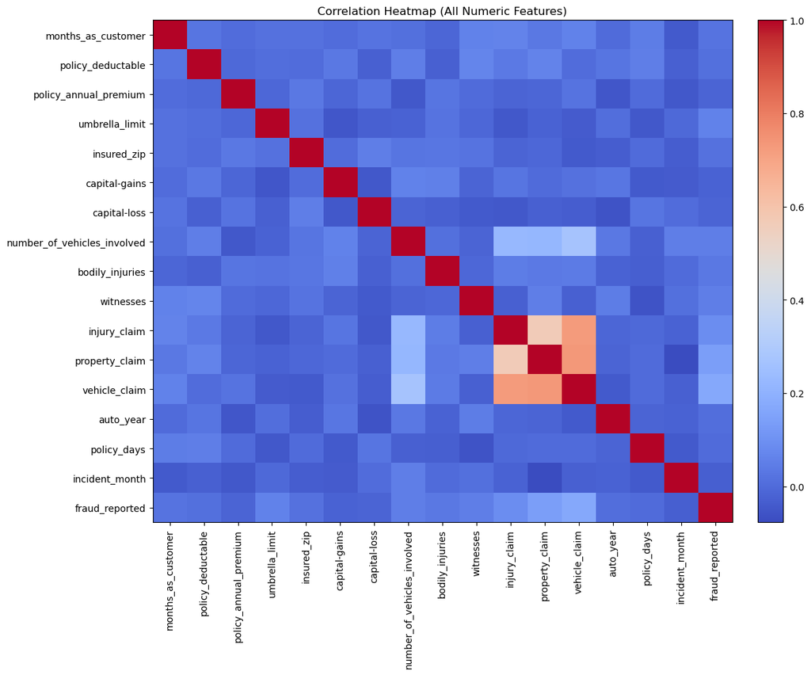

```python
# Create a correlation matrix for all numeric features, including the target variable
plt.figure(figsize=(12, 10))
corr = df[all_numeric].corr()
# Display the correlation matrix as a heatmap
im = plt.imshow(corr, interpolation='nearest', aspect='auto', cmap='coolwarm')
plt.colorbar(im, fraction=0.046, pad=0.04)
plt.xticks(range(len(all_numeric)), all_numeric, rotation=90) # Set x-axis labels
plt.yticks(range(len(all_numeric)), all_numeric) # Set y-axis labels
plt.title("Correlation Heatmap (All Numeric Features)")
plt.tight_layout()
plt.show() # Display the heatmap
```

## Split Training Data and Test Data for Modeling

With `stratify=y` we ensure training and test have same % of fraud data

```python
# Split the data into training and testing sets
# 20% of data for testing, 80% for training
# random_state ensures reproducibility of the split
# stratify=y ensures that the proportion of 'fraud_reported' (Y/N) is the same in both train and test sets
X_train, X_test, y_train, y_test = train_test_split(
    X, y, test_size=0.2, random_state=RANDOM_STATE, stratify=y
)

# Print the shapes of the resulting datasets to confirm the split
print("Train shape:", X_train.shape, "Test shape:", X_test.shape)
# Print the fraud rate (mean of y) in both train and test sets to verify stratification
print("Fraud rate in train:", y_train.mean())
print("Fraud rate in test:", y_test.mean())
```

```
Train shape: (800, 36) Test shape: (200, 36)
Fraud rate in train: 0.2475
Fraud rate in test: 0.245
```

## Building Classification Models

### Preprocessing Pipelines - Encoding and Scaling

- As most features are not normally distributed, we will use `MinMaxScaler`
- Using `OneHotEncoder` for categorical features
- For tree-based models, numeric features are passed through without encoding

```python
from sklearn.preprocessing import FunctionTransformer

# Numeric: standard scaling
numeric_transformer = Pipeline(steps=[
    ('scaler', MinMaxScaler()) #since most features are not normally distributed
])

# Categorical: convert to string, One-Hot Encoding
categorical_transformer = Pipeline(steps=[
    ('to_string', FunctionTransformer(lambda x: x.astype(str), validate=False)), # Convert all to string first
    ('onehot', OneHotEncoder(handle_unknown='ignore'))
])

preprocessor = ColumnTransformer(
    transformers=[
        ('num', numeric_transformer, numeric_features),
        ('cat', categorical_transformer, categorical_features)
    ]
)

# For tree-based models: numeric features are passed through (no scaling needed),
# and categorical features are one-hot encoded
preprocessor_tree = ColumnTransformer(
    transformers=[
        ('num', 'passthrough', numeric_features), # Pass numeric features directly
        ('cat', categorical_transformer, categorical_features) # One-hot encode categorical features
    ]
)
```

## Initialize Models

### Handling Class Imbalance

- Since data is moderately imbalanced, we are using `class_weight='balanced'` during model creation

```python
# Initialize an empty dictionary to store different models
models = {}

# Logistic Regression model with class weights for imbalance and increased max_iter for convergence
models['Logistic Regression'] = LogisticRegression(
    max_iter=1000,
    class_weight='balanced', # Automatically adjusts weights inversely proportional to class frequencies
    random_state=RANDOM_STATE
)

# Decision Tree Classifier with class weights for imbalance
models['Decision Tree'] = DecisionTreeClassifier(
    max_depth=None,
    min_samples_split=2,
    class_weight='balanced',
    random_state=RANDOM_STATE
)

# Random Forest Classifier with class weights for imbalance and parallel processing
models['Random Forest'] = RandomForestClassifier(
    n_estimators=400, # Number of trees in the forest
    class_weight='balanced',
    random_state=RANDOM_STATE,
    n_jobs=-1 # Use all available processors
)

# Support Vector Machine (SVM) Classifier with probability estimates and class weights
models['SVM'] = SVC(
    probability=True, # Enable probability estimates (needed for ROC AUC)
    class_weight='balanced',
    random_state=RANDOM_STATE
)

# K-Nearest Neighbors (KNN) Classifier
# Note: KNN does not inherently support `class_weight`. imbalance is partially addressed via other techniques.
models['KNN'] = KNeighborsClassifier(n_neighbors=5)
```

### Model Training and Prediction

```python
# List to store results of each model
results = []
# Dictionary to store trained pipelines for each model
trained_pipelines = {}

# Variables to track the overall best model based on ROC AUC
best_model_name_overall = None
best_model_pipe = None
best_roc_overall = -np.inf # Initialize with negative infinity

# Iterate through each model defined in the 'models' dictionary
for name, clf in models.items():
    print(f"\n===== Training base model: {name} =====")

    # Determine which preprocessor to use based on the model type
    current_preprocessor = preprocessor
    if name in ['Decision Tree', 'Random Forest']:
        current_preprocessor = preprocessor_tree

    # Create a pipeline: (preprocessing steps) -> (classifier)
    pipe = Pipeline(steps=[('preprocessor', current_preprocessor),
                           ('classifier', clf)])
    # Train the pipeline on the training data
    pipe.fit(X_train, y_train)
    # Store the trained pipeline
    trained_pipelines[name] = pipe

    # Make predictions on the test set
    y_pred = pipe.predict(X_test)

    # Get probability scores for ROC AUC calculation
    if hasattr(pipe.named_steps['classifier'], "predict_proba"):
        y_proba = pipe.predict_proba(X_test)[:, 1] # Probability of the positive class
    elif hasattr(pipe.named_steps['classifier'], "decision_function"):
        y_proba = pipe.decision_steps['classifier'].decision_function(X_test) # Decision scores for SVM
    else:
        y_proba = None # If neither is available, ROC AUC cannot be calculated

    # Calculate various evaluation metrics
    acc = accuracy_score(y_test, y_pred)
    prec = precision_score(y_test, y_pred, zero_division=0)
    rec = recall_score(y_test, y_pred, zero_division=0)
    f1 = f1_score(y_test, y_pred, zero_division=0)
    roc = roc_auc_score(y_test, y_proba) if y_proba is not None else np.nan # Calculate ROC AUC if probabilities are available

    # Append current model's results to the list
    results.append({
        'Model': name,
        'Accuracy': acc,
        'Precision': prec,
        'Recall': rec,
        'F1-score': f1,
        'ROC AUC': roc
    })

    # Print the evaluation metrics for the current model
    print("Accuracy :", acc)
    print("Precision:", prec)
    print("Recall   :", rec)
    print("F1-score :", f1)
    print("ROC AUC  :", roc)

    # Update the overall best model if current model has a higher ROC AUC
    if not np.isnan(roc) and roc > best_roc_overall:
        best_roc_overall = roc
        best_model_name_overall = name
        best_model_pipe = pipe

# Create a DataFrame from the results and sort by ROC AUC in descending order
results_df = pd.DataFrame(results).sort_values(by='ROC AUC', ascending=False)
results_df = results_df.reset_index(drop=True)

print("\nBase model performance:")
display(results_df) # Display the performance table

print("\nBest base model by ROC AUC:", best_model_name_overall, "with ROC AUC:", best_roc_overall)
```

```
===== Training base model: Logistic Regression =====
Accuracy : 0.82
Precision: 0.6181818181818182
Recall   : 0.6938775510204082
F1-score : 0.6538461538461539
ROC AUC  : 0.8298418705230437

===== Training base model: Decision Tree =====
Accuracy : 0.76
Precision: 0.5102040816326531
Recall   : 0.5102040816326531
F1-score : 0.5102040816326531
ROC AUC  : 0.6756318421408297

===== Training base model: Random Forest =====
Accuracy : 0.755
Precision: 0.5
Recall   : 0.2653061224489796
F1-score : 0.3466666666666667
ROC AUC  : 0.8283551831328558

===== Training base model: SVM =====
Accuracy : 0.845
Precision: 0.640625
Recall   : 0.8367346938775511
F1-score : 0.7256637168141593
ROC AUC  : 0.8368698472766589

===== Training base model: KNN =====
Accuracy : 0.735
Precision: 0.43333333333333335
Recall   : 0.2653061224489796
F1-score : 0.3291139240506329
ROC AUC  : 0.673672117853764

Base model performance:
```

|  | Model | Accuracy | Precision | Recall | F1-score | ROC AUC |
| --- | --- | --- | --- | --- | --- | --- |
| 0 | SVM | 0.845 | 0.640625 | 0.836735 | 0.725664 | 0.836870 |
| 1 | Logistic Regression | 0.820 | 0.618182 | 0.693878 | 0.653846 | 0.829842 |
| 2 | Random Forest | 0.755 | 0.500000 | 0.265306 | 0.346667 | 0.828355 |
| 3 | Decision Tree | 0.760 | 0.510204 | 0.510204 | 0.510204 | 0.675632 |
| 4 | KNN | 0.735 | 0.433333 | 0.265306 | 0.329114 | 0.673672 |

```
Best base model by ROC AUC: SVM with ROC AUC: 0.8368698472766589
```

### Feature importance based on ExtraTreesClassifier

```
Shape of X_train_processed: (800, 173)
Number of processed features: 173
ExtraTreesClassifier trained successfully.
```

[figure not shown]

```python
X_train_processed = preprocessor_tree.fit_transform(X_train)

# Get numeric feature names
numeric_names = numeric_features

# Get categorical feature names from the OneHotEncoder after fitting
# Access the 'cat' transformer, then the 'onehot' step within it
categorical_ohe_names = preprocessor_tree.named_transformers_['cat'].named_steps['onehot'].get_feature_names_out(categorical_features)

# Combine all feature names
processed_feature_names = list(numeric_names) + list(categorical_ohe_names)

print("Shape of X_train_processed:", X_train_processed.shape)
print("Number of processed features:", len(processed_feature_names))
from sklearn.ensemble import ExtraTreesClassifier

# Initialize the ExtraTreesClassifier with class weights to handle imbalance
et_clf = ExtraTreesClassifier(n_estimators=100, class_weight='balanced', random_state=RANDOM_STATE)

# Train the classifier on the preprocessed training data
et_clf.fit(X_train_processed, y_train)

print("ExtraTreesClassifier trained successfully.")

import pandas as pd
import matplotlib.pyplot as plt
import seaborn as sns

# Get feature importances from the trained ExtraTreesClassifier
feature_importances = et_clf.feature_importances_

# Create a DataFrame for better visualization
importance_df = pd.DataFrame({
    'Feature': processed_feature_names,
    'Importance': feature_importances
})

# Sort by importance in descending order
importance_df = importance_df.sort_values(by='Importance', ascending=False)

# Display the top 15 most important features
# print("Top 15 Feature Importances for ExtraTreesClassifier:")
# display(importance_df.head(15))

# Plot the top 15 feature importances
plt.figure(figsize=(8, 6))
sns.barplot(x='Importance', y='Feature', data=importance_df.head(10), palette='viridis')
plt.title('Top 15 Feature Importances (ExtraTreesClassifier)')
plt.xlabel('Importance')
plt.ylabel('Feature')
plt.tight_layout()
plt.show()
```

## Hyperparameter Tuning

```python
# Hyperparameter tuning for top-performing models (by ROC AUC)
top_n = 5  # number of top models to tune
top_models = results_df.sort_values(by='ROC AUC', ascending=False)['Model'].head(top_n).tolist()
print("Models selected for hyperparameter tuning:", top_models)

# Define search spaces for RandomizedSearchCV (using 'classifier__' prefix for the pipeline)
param_distributions = {
    'Logistic Regression': {
        'classifier__C': np.logspace(-3, 2, 20),
        'classifier__penalty': ['l1', 'l2'],
        'classifier__solver': ['liblinear']
    },
    'Random Forest': {
        'classifier__n_estimators': [100, 400, 600, 800, 1000],
        'classifier__max_depth': [None, 20, 30, 40, 50],
        'classifier__min_samples_split': [2, 3, 5, 7, 10],
        'classifier__min_samples_leaf': [1, 2, 4],
    },
    'SVM': {
        'classifier__C': np.logspace(-2, 2, 20),
        'classifier__gamma': ['scale', 'auto'],
        'classifier__kernel': ['rbf', 'linear', 'poly']
    },
    'Decision Tree': {
        'classifier__criterion': ['gini', 'entropy', 'log_loss'],
        'classifier__max_depth': [None, 5, 10, 20, 30],
        'classifier__min_samples_split': [2, 5, 10, 20],
        'classifier__min_samples_leaf': [1, 2, 4, 8],
        'classifier__max_features': [None, 'sqrt', 'log2'],
    },
    'KNN': {
        'classifier__n_neighbors': [3, 5, 7, 9, 11, 15, 21],
        'classifier__weights': ['uniform', 'distance'],
        'classifier__metric': ['euclidean', 'manhattan', 'minkowski'],
        'classifier__p': [1, 2],  # p=1 -> Manhattan, p=2 -> Euclidean
        'classifier__leaf_size': [20, 30, 40, 50]
    }
}

tuned_results = []
tuned_pipelines = {}

# Iterate through selected models for tuning
for name in top_models:
    if name not in param_distributions:
        print(f"\nNo hyperparameter search space defined for {name}; skipping tuning for this model.")
        continue

    print(f"\n===== Hyperparameter tuning for {name} =====")
    clf = models[name]
    # Use the appropriate preprocessor based on model type
    current_preprocessor = preprocessor
    if name in ['Decision Tree', 'Random Forest']:
        current_preprocessor = preprocessor_tree

    pipe = Pipeline(steps=[('preprocessor', current_preprocessor),
                           ('classifier', clf)])

    # Initialize RandomizedSearchCV for hyperparameter optimization
    rs = RandomizedSearchCV(
        estimator=pipe,
        param_distributions=param_distributions[name],
        n_iter=20, # Number of parameter settings that are sampled
        scoring='roc_auc',
        cv=3,
        verbose=1,
        random_state=RANDOM_STATE,
        n_jobs=-1 # Use all available processors
    )

    # Fit RandomizedSearchCV to find the best hyperparameters
    rs.fit(X_train, y_train)
    best_pipe = rs.best_estimator_
    tuned_pipelines[name + " (tuned)"] = best_pipe

    print("Best hyperparameters found:")
    print(rs.best_params_)

    # Evaluate tuned model on test set
    y_pred = best_pipe.predict(X_test)
    if hasattr(best_pipe.named_steps['classifier'], "predict_proba"):
        y_proba = best_pipe.predict_proba(X_test)[:, 1]
    elif hasattr(best_pipe.named_steps['classifier'], "decision_function"):
        y_proba = best_pipe.decision_function(X_test)
    else:
        y_proba = None

    # Calculate metrics for the tuned model
    acc = accuracy_score(y_test, y_pred)
    prec = precision_score(y_test, y_pred, zero_division=0)
    rec = recall_score(y_test, y_pred, zero_division=0)
    f1 = f1_score(y_test, y_pred, zero_division=0)
    roc = roc_auc_score(y_test, y_proba) if y_proba is not None else np.nan

    tuned_results.append({
        'Model': name + " (tuned)",
        'Accuracy': acc,
        'Precision': prec,
        'Recall': rec,
        'F1-score': f1,
        'ROC AUC': roc
    })

    print("Tuned Accuracy :", acc)
    print("Tuned Precision:", prec)
    print("Tuned Recall   :", rec)
    print("Tuned F1-score :", f1)
    print("Tuned ROC AUC  :", roc)

    # Update overall best model if tuning improved it
    if not np.isnan(roc) and roc > best_roc_overall:
        best_roc_overall = roc
        best_model_name_overall = name + " (tuned)"
        best_model_pipe = best_pipe

if len(tuned_results) > 0:
    tuned_results_df = pd.DataFrame(tuned_results).sort_values(by='ROC AUC', ascending=False)
    tuned_results_df = tuned_results_df.reset_index(drop=True)
    print("\nTuned model performance:")
    display(tuned_results_df)
else:
    tuned_results_df = pd.DataFrame()
    print("\nNo models were tuned (no search spaces defined for selected models).")

print("\nBest model overall (base or tuned):", best_model_name_overall)
print("Best ROC AUC overall:", best_roc_overall)
```

```
Models selected for hyperparameter tuning: ['SVM', 'Logistic Regression', 'Random Forest', 'Decision Tree', 'KNN']

===== Hyperparameter tuning for SVM =====
Fitting 3 folds for each of 20 candidates, totalling 60 fits
Best hyperparameters found:
{'classifier__kernel': 'linear', 'classifier__gamma': 'auto', 'classifier__C': np.float64(0.18329807108324356)}
Tuned Accuracy : 0.845
Tuned Precision: 0.6363636363636364
Tuned Recall   : 0.8571428571428571
Tuned F1-score : 0.7304347826086957
Tuned ROC AUC  : 0.8455196648195703

===== Hyperparameter tuning for Logistic Regression =====
Fitting 3 folds for each of 20 candidates, totalling 60 fits
Best hyperparameters found:
{'classifier__solver': 'liblinear', 'classifier__penalty': 'l1', 'classifier__C': np.float64(1.438449888287663)}
Tuned Accuracy : 0.81
Tuned Precision: 0.6037735849056604
Tuned Recall   : 0.6530612244897959
Tuned F1-score : 0.6274509803921569
Tuned ROC AUC  : 0.8187592917961886

===== Hyperparameter tuning for Random Forest =====
Fitting 3 folds for each of 20 candidates, totalling 60 fits
Best hyperparameters found:
{'classifier__n_estimators': 100, 'classifier__min_samples_split': 2, 'classifier__min_samples_leaf': 1, 'classifier__max_depth': None}
Tuned Accuracy : 0.775
Tuned Precision: 0.5666666666666667
Tuned Recall   : 0.3469387755102041
Tuned F1-score : 0.43037974683544306
Tuned ROC AUC  : 0.8398432220570348

===== Hyperparameter tuning for Decision Tree =====
Fitting 3 folds for each of 20 candidates, totalling 60 fits
Best hyperparameters found:
{'classifier__min_samples_split': 20, 'classifier__min_samples_leaf': 8, 'classifier__max_features': None, 'classifier__max_depth': 5, 'classifier__criterion': 'gini'}
Tuned Accuracy : 0.84
Tuned Precision: 0.6307692307692307
Tuned Recall   : 0.8367346938775511
Tuned F1-score : 0.7192982456140351
Tuned ROC AUC  : 0.8424111366400865

===== Hyperparameter tuning for KNN =====
Fitting 3 folds for each of 20 candidates, totalling 60 fits
Best hyperparameters found:
{'classifier__weights': 'uniform', 'classifier__p': 2, 'classifier__n_neighbors': 21, 'classifier__metric': 'euclidean', 'classifier__leaf_size': 30}
Tuned Accuracy : 0.765
Tuned Precision: 0.625
Tuned Recall   : 0.10204081632653061
Tuned F1-score : 0.17543859649122806
Tuned ROC AUC  : 0.7522638194350589

Tuned model performance:
```

|  | Model | Accuracy | Precision | Recall | F1-score | ROC AUC |
| --- | --- | --- | --- | --- | --- | --- |
| 0 | SVM (tuned) | 0.845 | 0.636364 | 0.857143 | 0.730435 | 0.845520 |
| 1 | Decision Tree (tuned) | 0.840 | 0.630769 | 0.836735 | 0.719298 | 0.842411 |
| 2 | Random Forest (tuned) | 0.775 | 0.566667 | 0.346939 | 0.430380 | 0.839843 |
| 3 | Logistic Regression (tuned) | 0.810 | 0.603774 | 0.653061 | 0.627451 | 0.818759 |
| 4 | KNN (tuned) | 0.765 | 0.625000 | 0.102041 | 0.175439 | 0.752264 |

```
Best model overall (base or tuned): SVM (tuned)
Best ROC AUC overall: 0.8455196648195703
```

## Results Comparison

### Base performance

```python
# Display base model performance results
print("\nBase model performance:")
display(results_df)

# Print the best base model based on ROC AUC
print("\nBest base model by ROC AUC:", best_model_name_overall, "with ROC AUC:", best_roc_overall)
```

```
Base model performance:
```

|  | Model | Accuracy | Precision | Recall | F1-score | ROC AUC |
| --- | --- | --- | --- | --- | --- | --- |
| 0 | SVM | 0.845 | 0.640625 | 0.836735 | 0.725664 | 0.836870 |
| 1 | Logistic Regression | 0.820 | 0.618182 | 0.693878 | 0.653846 | 0.829842 |
| 2 | Random Forest | 0.755 | 0.500000 | 0.265306 | 0.346667 | 0.828355 |
| 3 | Decision Tree | 0.760 | 0.510204 | 0.510204 | 0.510204 | 0.675632 |
| 4 | KNN | 0.735 | 0.433333 | 0.265306 | 0.329114 | 0.673672 |

```
Best base model by ROC AUC: SVM (tuned) with ROC AUC: 0.8455196648195703
```

```
Displaying Confusion Matrix for: SVM
```

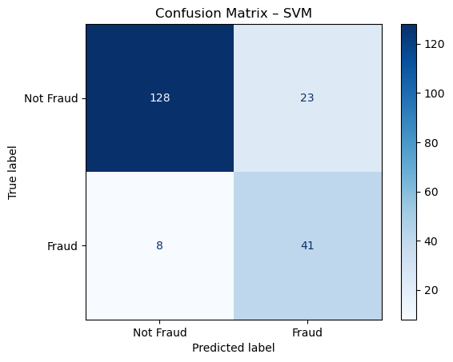

```
Classification report for best base model (SVM):
              precision    recall  f1-score   support

   Not Fraud       0.94      0.85      0.89       151
       Fraud       0.64      0.84      0.73        49

    accuracy                           0.84       200
   macro avg       0.79      0.84      0.81       200
weighted avg       0.87      0.84      0.85       200
```

```python
from sklearn.metrics import confusion_matrix, ConfusionMatrixDisplay
import matplotlib.pyplot as plt

# Identify the best base model from the initial results
best_base_model_name = results_df.iloc[0]['Model'] # results_df was already sorted by ROC AUC
best_base_model_pipe = trained_pipelines[best_base_model_name]

print(f"Displaying Confusion Matrix for: {best_base_model_name}")

# Make predictions using the best base model
y_pred_base = best_base_model_pipe.predict(X_test)

# Calculate the confusion matrix
cm_base = confusion_matrix(y_test, y_pred_base)

plt.figure(figsize=(4, 4))
# Using ConfusionMatrixDisplay for a more modern plot
disp = ConfusionMatrixDisplay(confusion_matrix=cm_base, display_labels=['Not Fraud', 'Fraud'])
disp.plot(cmap=plt.cm.Blues, values_format='d')
plt.title(f"Confusion Matrix – {best_base_model_name}")
plt.grid(False) # Turn off grid for confusion matrix plot
plt.show()

print(f"\nClassification report for best base model ({best_base_model_name}):")
print(classification_report(y_test, y_pred_base, target_names=['Not Fraud', 'Fraud']))
```

**Overall, the best base model (SVM) shows good performance, especially in identifying fraudulent cases (high recall for 'Fraud'), though there's a trade-off with precision (some false alarms).**

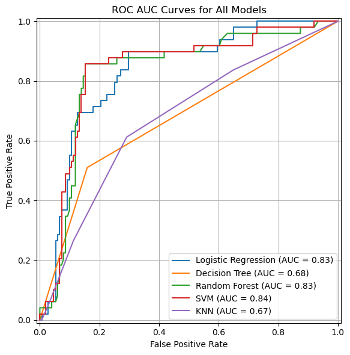

```python
from sklearn.metrics import RocCurveDisplay
import matplotlib.pyplot as plt

# Create a figure for the ROC AUC plot with a specified size
plt.figure(figsize=(8, 6))
ax = plt.gca()

# Initialize y_proba to None before iterating
y_proba = None

# Iterate through each trained pipeline to plot its ROC curve
for name, pipe in trained_pipelines.items():
    # Check if the classifier has predict_proba (for most classifiers)
    if hasattr(pipe.named_steps['classifier'], "predict_proba"):
        y_proba = pipe.predict_proba(X_test)[:, 1] # Probability of the positive class
    elif hasattr(pipe.named_steps['classifier'], "decision_function"):  #decision_function (for SVM)
        y_proba = pipe.decision_function(X_test) # Decision scores for SVM

    # If probabilities are available, plot the ROC curve
    if y_proba is not None:
        RocCurveDisplay.from_predictions(y_test, y_proba, name=name, ax=ax)
    else:
        print(f"Skipping {name}: No predict_proba or decision_function available.")

plt.title('ROC AUC Curves for All Models')
plt.xlabel('False Positive Rate')
plt.ylabel('True Positive Rate')
plt.grid(True)
plt.tight_layout()
plt.legend()
plt.show()
```

## Performance after Hyperparameter tuning

```python
# Display tuned model performance results
if len(tuned_results) > 0:
    tuned_results_df = pd.DataFrame(tuned_results).sort_values(by='ROC AUC', ascending=False)
    tuned_results_df = tuned_results_df.reset_index(drop=True)
    print("\nTuned model performance:")
    display(tuned_results_df)
else:
    tuned_results_df = pd.DataFrame()
    print("\nNo models were tuned (no search spaces defined for selected models).")

# Print the overall best model (either base or tuned) and its ROC AUC score
print("\nBest model overall (base or tuned):", best_model_name_overall)
print("Best ROC AUC overall:", best_roc_overall)
```

```
Tuned model performance:
```

|  | Model | Accuracy | Precision | Recall | F1-score | ROC AUC |
| --- | --- | --- | --- | --- | --- | --- |
| 0 | SVM (tuned) | 0.845 | 0.636364 | 0.857143 | 0.730435 | 0.845520 |
| 1 | Decision Tree (tuned) | 0.840 | 0.630769 | 0.836735 | 0.719298 | 0.842411 |
| 2 | Random Forest (tuned) | 0.775 | 0.566667 | 0.346939 | 0.430380 | 0.839843 |
| 3 | Logistic Regression (tuned) | 0.810 | 0.603774 | 0.653061 | 0.627451 | 0.818759 |
| 4 | KNN (tuned) | 0.765 | 0.625000 | 0.102041 | 0.175439 | 0.752264 |

```
Best model overall (base or tuned): SVM (tuned)
Best ROC AUC overall: 0.8455196648195703
```

```
Best model selected for final evaluation: SVM (tuned)
Confusion matrix:
 [[127  24]
 [  7  42]]
```

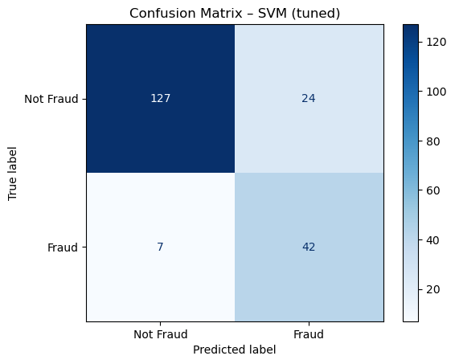

```
Classification report for best model:
              precision    recall  f1-score   support

   Not Fraud       0.95      0.84      0.89       151
       Fraud       0.64      0.86      0.73        49

    accuracy                           0.84       200
   macro avg       0.79      0.85      0.81       200
weighted avg       0.87      0.84      0.85       200
```

```python
# Use the best model found (either base or tuned) for final evaluation
print("Best model selected for final evaluation:", best_model_name_overall)
best_pipe = best_model_pipe

# Make predictions using the best overall model
y_pred_best = best_pipe.predict(X_test)

# Calculate and print the confusion matrix
cm = confusion_matrix(y_test, y_pred_best)
print("Confusion matrix:\n", cm)

# Plot the confusion matrix
plt.figure(figsize=(4, 4))
# Using ConfusionMatrixDisplay for a more modern plot
disp = ConfusionMatrixDisplay(confusion_matrix=cm, display_labels=['Not Fraud', 'Fraud'])
disp.plot(cmap=plt.cm.Blues, values_format='d')
plt.title(f"Confusion Matrix – {best_model_name_overall}")
plt.grid(False)
plt.show()

# Print the classification report for the best overall model
print("\nClassification report for best model:")
print(classification_report(y_test, y_pred_best, target_names=['Not Fraud', 'Fraud']))
```

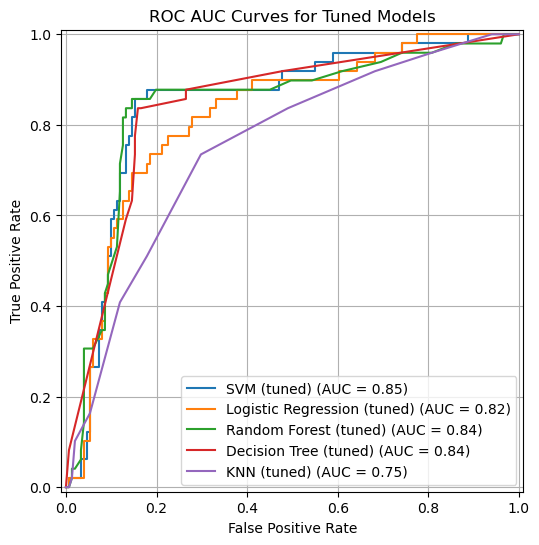

```python
from sklearn.metrics import RocCurveDisplay
import matplotlib.pyplot as plt

# Create a figure for the ROC AUC plot with a specified size
plt.figure(figsize=(8, 6)) # Reduced figure size
ax = plt.gca()

# Initialize y_proba to None before iterating
y_proba = None

# Iterate through each tuned pipeline to plot its ROC curve
for name, pipe in tuned_pipelines.items():
    # Check if the classifier has predict_proba (for most classifiers)
    if hasattr(pipe.named_steps['classifier'], "predict_proba"):
        y_proba = pipe.predict_proba(X_test)[:, 1] # Probability of the positive class
    elif hasattr(pipe.named_steps['classifier'], "decision_function"): # decision_function (for SVM)
        y_proba = pipe.decision_function(X_test) # Decision scores for SVM

    # If probabilities are available, plot the ROC curve
    if y_proba is not None:
        RocCurveDisplay.from_predictions(y_test, y_proba, name=name, ax=ax)
    else:
        print(f"Skipping {name}: No predict_proba or decision_function available.")

plt.title('ROC AUC Curves for Tuned Models')
plt.xlabel('False Positive Rate')
plt.ylabel('True Positive Rate')
plt.grid(True)
plt.legend()
plt.show()
```

## Best Model

The best performing model based on ROC AUC (and Recall) scores is **`SVM (tuned)`**, which achieved the following metrics for the **'Fraud'** class:

- **ROC AUC:** 0.8455
- **Recall:** 0.8571
- **Accuracy:** 0.8450
- **Precision:** 0.6363
- **f1-score:** 0.7304

This indicates that out of all instances predicted as fraud, approximately 64% were actually fraudulent (precision). Among all actual fraudulent cases, approximately 86% were correctly identified by the model (recall). The F1-score of 0.73 provides a balanced measure of both precision and recall for the fraud class.

## Conclusion & Future Steps

Our Goal was to find best performing classification model for target `fraud_reported` (Y/N, binary classification, imbalanced)

We performed following steps:

- Explored the dataset (**EDA**) and understood the distributions of features
- Cleaned the data, handling missing values
- Conducted feature engineering by dropping few columns, creating new columns by binning data
- Encoded categorical features using `OneHotEncoder` and scaled numeric features using `MinMaxScaler`
- Addressed class imbalance (~25% fraud) using `class weights`
- Trained and evaluated multiple supervised classification models for detecting fraud - **Logistic Regression, Decision Tree, Random Forest, SVM, KNN**
- Performed `hyperparameter tuning` for the models and selected the best model overall based on ROC AUC (and Recall)
- **SVM (tuned)** was found to be the best model based on ROC AUC (and Recall)

**Possible next steps for improving the project**:

- Build and compare other classification models including Boosting
- More extensive hyperparameter tuning
- More advanced feature engineering based on domain knowledge
- Try different balancing techniques like SMOTE
- Precision-Recall curve and analysis
- Cost-sensitive evaluation using custom metrics reflecting business impact of false positives/negatives.

Navigate to Top